# Project for Practical Machine Learning

Jacques Sauve

December 15, 2015

# Executive Summary

Two models were produced and compared, a random forest model on the original predictors and another random forest on the principal components obtained from PCA. The best model has expected testing (out-of-sample) accuracy of 99,3%. Finally, 20 test cases were predicted and submitted for automatic evaluation; all were correct.

# Exploratory Analysis

The training data are available here: https://d396qusza40orc.cloudfront.net/predmachlearn/pml-training.csv

The test data (used for validation) are available here: https://d396qusza40orc.cloudfront.net/predmachlearn/pml-testing.csv

We first look at the data by hand using a shell (`more` command) or a text editor and we discover that NA can be represented by NA or “”. With this information, we can read the data in an R data frame.

- There are 19622 training samples with 160 columns and 20 validation samples.
- We have enough data to split the training data in a training and a testing set. This is not strictly necessary, since the whole training data could be used with cross-validation to estimate the testing (out-of-sample) accuracy. However, it is a recommended practice when enough data are available, since it gives a more precise estimate of the testing accuracy.

Therefore, we will train on 70% of the data from `pml-training.csv` and 30% will be used to estimate the testing accuracy. Final validation will be done on the 20 cases in `pml-testing.csv`.

## Examine data format, data preparation

It is crucial to make sure that the data are read in the correct format (factor, character, int, numeric) to allow model training to be done efficiently.

```r
str(df)
```

[output not shown]

Looking at str(df) reveals that:

- There are a lot of missing data: since they are concentrated in several columns, it is better to remove the columns, not the rows containing NA.
- When read in, some numerical columns are automatically converted to factors because they contain a string “#DIV/0!” These should all be converted to numeric, the reason being that several models (ex. random forests) have runtime complexity that is exponential in the number of factor levels and these numeric factors were converted to factors with hundreds of levels!
  - Here is an example:
    - kurtosis_roll_belt: Factor w/ 397 levels …
  - This would make many model techniques essentially unusable.

```r
# Find columns that have a certain pattern and convert them to numeric
convert.factor.to.numeric = function(df, expr) {
    special.numeric.columns = which(apply(df, 2, function(x) any(grepl(expr, x))))
    # convert these columns to numeric: may cause warnings due to NAs
    df[special.numeric.columns] <-
        lapply(df[special.numeric.columns], function(x) as.numeric(as.character(x)))
    return (df)
}
df.clean = convert.factor.to.numeric(df, '#DIV/0!')
df.validation.clean = convert.factor.to.numeric(df.validation, '#DIV/0!')

# now remove columns with NAs
which.cols.need.to.go = sapply(df.clean, function(x) sum(is.na(x)) > 0)
df.clean = df.clean[!which.cols.need.to.go]
which.cols.need.to.go = sapply(df.validation.clean, function(x) sum(is.na(x)) > 0)
df.validation.clean = df.validation.clean[!which.cols.need.to.go]
ncol(df.clean)
```

```
## [1] 60
```

- The first 7 predictors (IDs, dates) have nothing to do with the wearable accelerometers, so remove them:

```r
names(df)[1:7]
```

```
## [1] "X"                    "user_name"            "raw_timestamp_part_1"
## [4] "raw_timestamp_part_2" "cvtd_timestamp"       "new_window"
## [7] "num_window"
```

```r
df.clean = df.clean[-(1:7)]
```

- We now have 53 columns (52 predictors and the `classe` response).

# Classification Models

We will use the `caret` package, providing more than 150 models with unified a interface.

- Reference: [caret package documentation](http://topepo.github.io/caret)

We need to choose a model technique. We have many predictors (p=53) but we have enough data (n) not to worry about using special methods for n < p. We first choose a random forest (RF) model because RF is considered to be one of the very best classification techniques. The technique is not very good in terms of interpretability but we are looking for accuracy in this exercise, not interpretability. The model will be trained and tested on the split data (70% training, 30% test). Then at least one more model will be trained and compared to the RF.

## Useful function

```r
# calculate the accuracy of a classification model compared to the real data
calc.accuracy = function(model, testing) {
    pred = predict(model, testing)
    cm = confusionMatrix(pred, testing$classe)
    return (cm$overall['Accuracy'])
}
```

## Prepare the training and testing data

- The data are split as follows: 70% training, 30% testing.

```r
set.seed(1)
train.proportion = 0.7
trainIndex = createDataPartition(df.clean$classe, p = train.proportion, list=FALSE)
training = df.clean[trainIndex,]
testing = df.clean[-trainIndex,]
dim(training)
```

```
## [1] 13737    53
```

```r
dim(testing)
```

```
## [1] 5885   53
```

## Train and test a random forest

We have made the following choices:

- Use the `rf` method from the `caret` package to train a random forest.
- Accept the default of 500 trees to be grown; the `randomForest` (used by `caret`) documentation states: “This should not be set to too small a number, to ensure that every input row gets predicted at least a few times.”
- The tuning parameter `mtry` (Number of predictors randomly chosen at each split in the tree) will automatically be optimized by the training algorithm during cross-validation.
- In order to keep the algorithm as fast as possible (there are many predictors), we choose:
  - a faster cross-validation method: out-of-bag (`oob`);
  - a value of 10 for `nodesize`, so that tree nodes will not contain less than 10 samples, making the tree smaller.
  - predictors that have near-zero-variance will be removed by pre-processing (`preProcess=c('nzv')`)
- These decisions can be reviewed later if the model accuracy is low.

```r
predictors = training[ , -which(names(training) %in% c("classe"))]
response = training[,'classe']
#start = Sys.time()
fit.rf <- train(predictors, response,
                nodesize=10,
                allowParallel=TRUE, do.trace=FALSE,
                trControl = trainControl(method ='oob'),
                method="rf", preProcess=c('nzv'))
#end = Sys.time()
#print(end - start)
print(fit.rf)
```

```
## Random Forest
##
## 13737 samples
##    52 predictor
##     5 classes: 'A', 'B', 'C', 'D', 'E'
##
## Pre-processing:  (None)
## Resampling results across tuning parameters:
##
##   mtry  Accuracy   Kappa
##    2    0.9871151  0.9836984
##   27    0.9917012  0.9895024
##   52    0.9828929  0.9783583
##
## Accuracy was used to select the optimal model using  the largest value.
## The final value used for the model was mtry = 27.
```

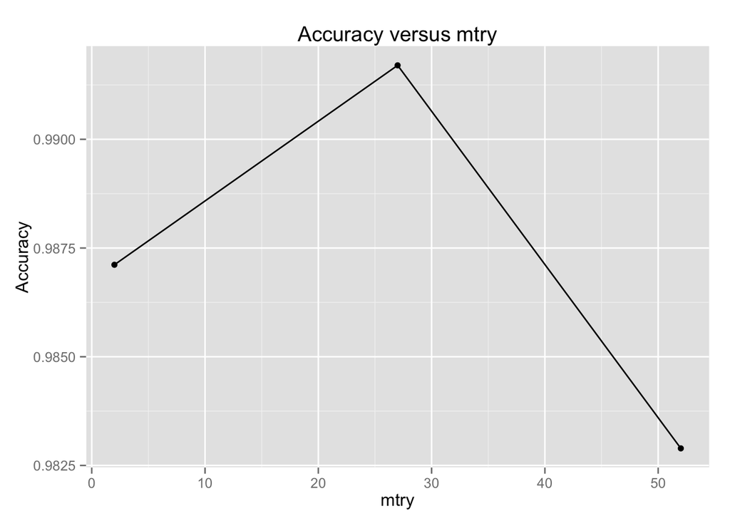

```r
ggplot(fit.rf$result, aes(x = mtry, y = Accuracy)) +
    geom_point() +
    geom_line() +
    ggtitle('Accuracy versus mtry')
```

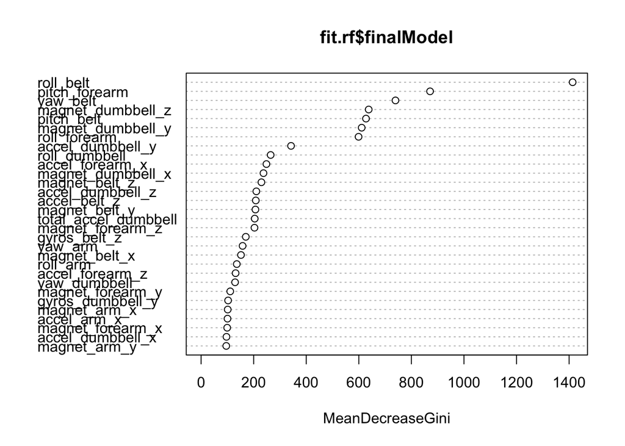

```r
varImpPlot(fit.rf$finalModel)
```

```r
tr.acc = max(fit.rf$results$Accuracy)
cat('Training accuracy: ', tr.acc, '\n')
```

```
## Training accuracy:  0.9917012
```

```r
tst.acc = calc.accuracy(fit.rf, testing)
cat('Testing accuracy: ', tst.acc, '\n')
```

```
## Testing accuracy:  0.9928632
```

- The above information shows that:
  - The best value of mtry found was 27 (see ouput of fit.rf and the first plot);
  - The most important predictors of the output class (`roll_belt`, `pitch_forearm`, …);
  - The training accuracy is 0.9917012 and the testing accuracy is 0.9928632.

## Model with Principal Component Analysis before Random Forest

- With such accuracy, we really don’t need a second model, but let us use PCA and then apply the result to a random forest to see if improvements result.

```r
#start = Sys.time()
fit.pca.rf <- train(predictors, response,
                nodesize=10,
                allowParallel=TRUE, do.trace=FALSE,
                trControl = trainControl(method ='oob'),
                method="rf", preProcess=c('nzv', 'pca'))
#end = Sys.time()
#print(end - start)
print(fit.pca.rf)
```

```
## Random Forest
##
## 13737 samples
##    52 predictor
##     5 classes: 'A', 'B', 'C', 'D', 'E'
##
## Pre-processing: principal component signal extraction (52), centered
##  (52), scaled (52)
## Resampling results across tuning parameters:
##
##   mtry  Accuracy   Kappa
##    2    0.9649123  0.9556055
##   27    0.9515178  0.9386769
##   52    0.9528281  0.9403418
##
## Accuracy was used to select the optimal model using  the largest value.
## The final value used for the model was mtry = 2.
```

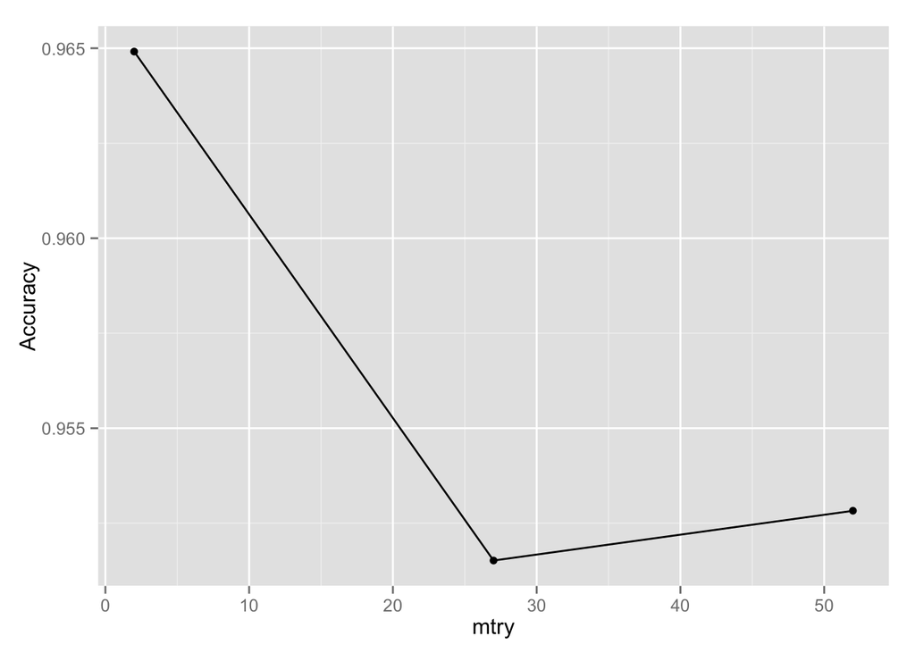

```r
ggplot(fit.pca.rf$result, aes(x = mtry, y = Accuracy)) +
   geom_point() +geom_line()
```

```r
tr.acc.pca = max(fit.pca.rf$results$Accuracy)
cat('Training accuracy: ', tr.acc.pca, '\n')
```

```
## Training accuracy:  0.9649123
```

```r
tst.acc.pca = calc.accuracy(fit.pca.rf, testing)
cat('Testing accuracy: ', tst.acc.pca, '\n')
```

```
## Testing accuracy:  0.9643161
```

- The expected accuracy (0.9643161) is unfortunately worse and we keep the initial random forest model.

# Validation

- We now calculate the `classe` response for the 20 validation samples.

```r
pred.validation = predict(fit.rf, newdata=df.validation.clean)

pml_write_files = function(x, dir){
  n = length(x)
  for(i in 1:n){
    filename = paste0(dir,'/problem_id_',i,".txt")
    write.table(x[i],file=filename,quote=FALSE,row.names=FALSE,col.names=FALSE)
  }
}
pml_write_files(pred.validation, 'predictions')
```

The final predictions for the 20 validation samples are: B, A, B, A, A, E, D, B, A, A, B, C, B, A, E, E, A, B, B, B. These values were submitted for automatic correction and are all correct.